# HW6

Xiaotian Ding

2019/2/27

# 9.11

a

```r
setwd("~/Desktop/Study in NU/Winter/Regression analysis/Regression analysis/Archive/Chapter  9 Data Sets")
data.911<- read.table("CH09PR10.txt")
colnames(data.911)<-c("proficiency","test 1","test 2","test 3","test 4")
y.911<-data.911$"proficiency"
x1f.911<-data.911$`test 1`-mean(data.911$`test 1`)
x2f.911<-data.911$`test 2`-mean(data.911$`test 2`)
x3f.911<-data.911$`test 3`-mean(data.911$`test 3`)
x4f.911<-data.911$`test 4`-mean(data.911$`test 4`)
library(leaps)
Result<- leaps(x= cbind(x1f.911,x2f.911,x3f.911,x4f.911),y=data.911[,1],names=names(data.911)[2:5],method = "adjr2")
Result2<-cbind(Result$which,Result$adjr2)
Result2[order(Result$adjr2,decreasing = "TRUE"),]
```

```
##   test 1 test 2 test 3 test 4
## 3      1      0      1      1 0.9560482
## 4      1      1      1      1 0.9554702
## 2      1      0      1      0 0.9269043
## 3      1      1      1      0 0.9246779
## 2      0      0      1      1 0.8660988
## 3      0      1      1      1 0.8616797
## 3      1      1      0      1 0.8232664
## 2      1      0      0      1 0.7984716
## 1      0      0      1      0 0.7962344
## 2      0      1      1      0 0.7884436
## 2      0      1      0      1 0.7635916
## 1      0      0      0      1 0.7452170
## 2      1      1      0      0 0.4154853
## 1      1      0      0      0 0.2326452
## 1      0      1      0      0 0.2142762
```

```r
subfit1.911<-lm(y.911~x1f.911+x3f.911+x4f.911)
subfit2.911<-lm(y.911~x1f.911+x2f.911+x3f.911+x4f.911)
subfit3.911<-lm(y.911~x1f.911+x3f.911)
subfit4.911<-lm(y.911~x1f.911+x2f.911+x3f.911)
subfit1.911$coefficients
```

```
## (Intercept)     x1f.911     x3f.911     x4f.911
##  92.2000000   0.2963260   1.3569675   0.5174211
```

```r
subfit2.911$coefficients
```

```
## (Intercept)     x1f.911     x2f.911     x3f.911     x4f.911
## 92.20000000  0.29572537  0.04828772  1.30601100  0.51981909
```

```r
subfit3.911$coefficients
```

```
## (Intercept)     x1f.911     x3f.911
##  92.2000000   0.3484575   1.8232055
```

```r
subfit4.911$coefficients
```

```
## (Intercept)     x1f.911     x2f.911     x3f.911
## 92.20000000  0.34813384  0.04353454  1.77921293
```

First Order:

Subset model 1:E{y}=92.2000000+0.2963260*x1+1.3569675*x3+0.5174211*x4

Subset model 2:E{y}=92.20000000+0.29572537*x1+0.04828772*x2+1.30601100*x3+0.51981909*x4

Subset model 3:E{y}=92.2000000+0.3484575*x1+1.8232055*x3

Subset model 4:E{y}=92.2000000+0.34813384*x1+0.04353454*x2+1.77921293*x3

We can use Cp method to determine which variance should be considered into model. When the Cp for select model is close to p, the select model is appropriate one. We can also use stepwise method to choose best model.

```r
Base= lm(y.911~1, data=data.911)
Retailer<- lm(data.911$proficiency~ ., data = data.911)
step(Base,scope=list(upper=Retailer,lower=~1),direction="both",trace=FALSE)
```

```
##
## Call:
## lm(formula = y.911 ~ `test 3` + `test 1` + `test 4`, data = data.911)
##
## Coefficients:
## (Intercept)     `test 3`     `test 1`     `test 4`
##   -124.2000       1.3570       0.2963       0.5174
```

Best model: E{y}=-124.2000+1.3570*x3+0.2963*x1+0.5174*x4

# 10.10

```r
setwd("~/Desktop/Study in NU/Winter/Regression analysis/Regression analysis/Archive/Chapter  6 Data Sets")
data.1010<- read.table("CH06PR09.txt")
colnames(data.1010)<- c("y.1010","x1.1010","x2.1010","x3.1010")
fit.1010<- lm(y.1010~x1.1010+x2.1010+x3.1010,data = data.1010)
rstudent(fit.1010)
```

```
##           1           2           3           4           5           6
## -0.22408724  1.22549009 -0.17058921 -0.38465346  0.59079243  0.19612403
##           7           8           9          10          11          12
## -1.11220903 -1.20529304 -0.97317140  2.03651764  0.93459516 -0.23775605
##          13          14          15          16          17          18
## -0.41516269 -1.57563574  0.16177701 -0.94585538  1.27571169 -0.53946536
##          19          20          21          22          23          24
##  0.76695374 -1.30688333 -0.37866873  0.09348669 -0.86199416  0.58204380
##          25          26          27          28          29          30
##  0.34737819 -0.16427705  0.55395260 -0.41694583  0.43222641 -0.16381817
##          31          32          33          34          35          36
## -0.98793522 -1.99766654  1.58403006  1.70041654 -1.66686277 -0.48548061
##          37          38          39          40          41          42
## -0.98726030  2.11878596 -0.77401415  2.17827186  0.20535372  0.59660183
##          43          44          45          46          47          48
##  0.88556630  0.43246959  0.27680521 -0.56690329 -1.04682238 -0.23443689
##          49          50          51          52
##  0.01909697  1.63020460 -1.37470514  0.45278959
```

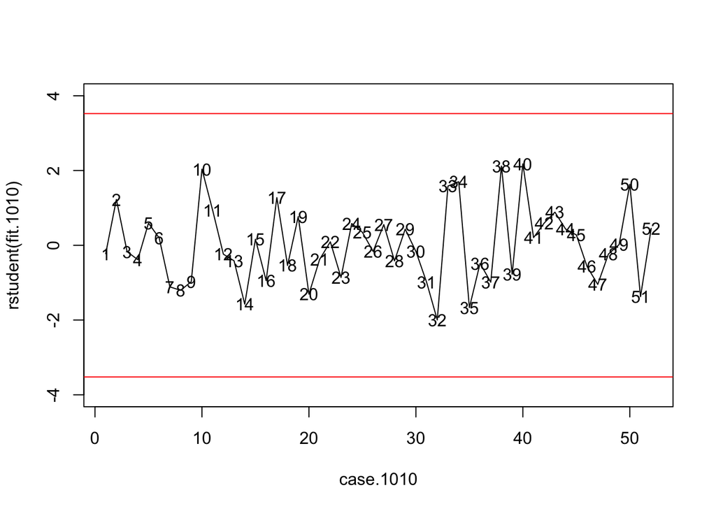

```r
n.1010a=dim(data.1010)[1]
a.1010a=0.05
p.1010a=4
case.1010= c(1:n.1010a)
plot(case.1010,rstudent(fit.1010),type = "l", ylim = c(-4,4))
text(case.1010,rstudent(fit.1010))
qt.1010=qt(1-a.1010a/(2*n.1010a),n.1010a-p.1010a-1)
abline(h=qt.1010,col=2)
abline(h=-qt.1010,col=2)
```

```r
which(abs(rstudent(fit.1010))>=qt.1010)
```

```
## named integer(0)
```

H0: Not outlier

Ha: outlier

RR: abs(ti)>= t(1-a/(2n);n-p-1)

Conclusion: There is no Y outliers.

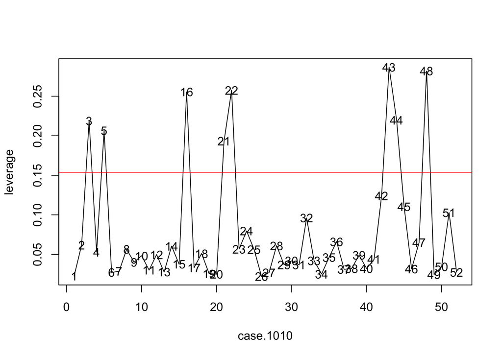

```r
leverage= hatvalues(fit.1010)
plot(case.1010,leverage,type = "l")
text(case.1010,leverage)
abline(h=2*p.1010a/n.1010a,col=2)
```

```r
whichones= which(leverage>2*p.1010a/n.1010a)
leverage[whichones]
```

```
##         3         5        16        21        22        43        44
## 0.2188773 0.2063282 0.2554249 0.1936047 0.2577199 0.2868586 0.2200236
##        48
## 0.2817766
```

These cases have potiental probability to be x outlier within the method of hat matrix.

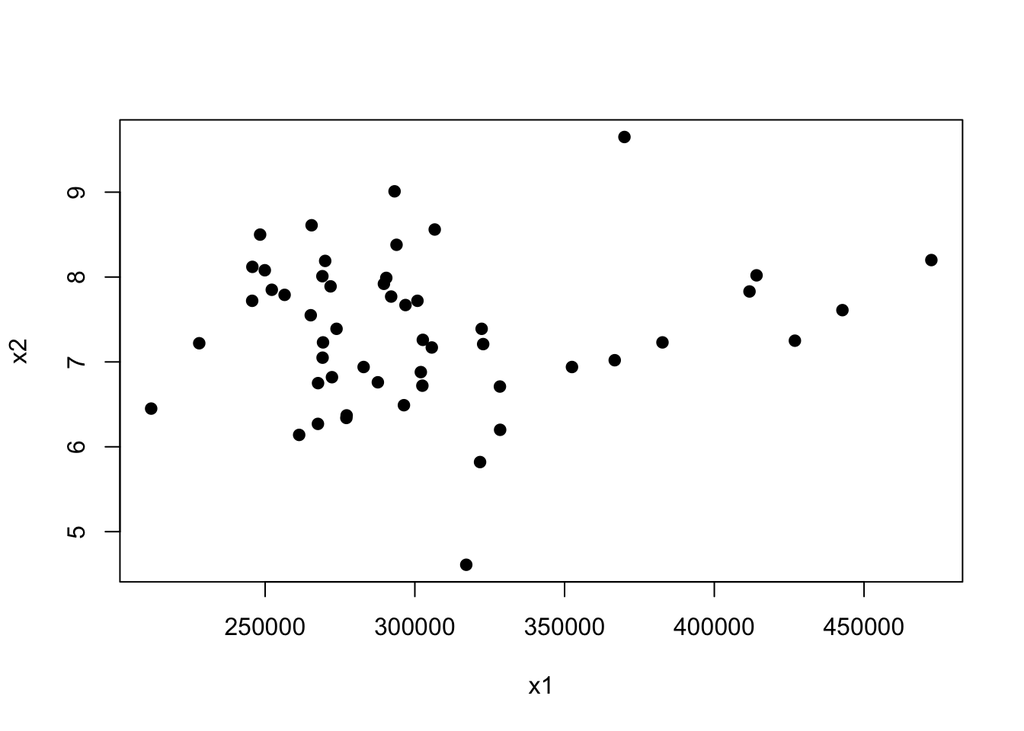

```r
x1.1010=data.1010$x1.1010
x2.1010=data.1010$x2.1010
x3.1010=data.1010$x3.1010
plot(x1.1010,x2.1010, xlab = "x1",ylab = "x2",pch=19)
```

```r
x.1010=cbind(rep(1,n.1010a),x1.1010,x2.1010,x3.1010)
xnew=c(1,300000,7.2,0)
hnn=t(xnew)%*%solve(t(x.1010)%*%x.1010)%*%xnew
hnn
```

```
##            [,1]
## [1,] 0.02221728
```

```r
range(leverage)
```

```
## [1] 0.02189441 0.28685861
```

From the plot of x2 against x1, both x2 and x1 applied in the prediction is in the range.

After using the 10.29, the hnew,new is in hii range. Thus, there are no extrapolation.

```r
IM=influence.measures(fit.1010)
abs(IM$infmat[c(16,22,43,48,10,32,38,40),c(1:5,7)])
```

```
##        dfb.1_   dfb.x1.1    dfb.x2.1   dfb.x3.1      dffit       cook.d
## 16 0.24768867 0.05978171 0.324814936 0.45210042 0.55399026 0.0768950835
## 22 0.03042319 0.02528712 0.018701755 0.04464552 0.05508583 0.0007746088
## 43 0.35779734 0.13384205 0.326179735 0.35662759 0.56165186 0.0792193145
## 48 0.04498580 0.09384229 0.009013941 0.10221538 0.14684146 0.0054988670
## 10 0.36407495 0.10440317 0.314158747 0.06334626 0.45863297 0.0493501187
## 32 0.40954150 0.09134173 0.570832219 0.16520616 0.65107706 0.0997597379
## 38 0.09961479 0.08273847 0.208364674 0.12700868 0.38551766 0.0346380312
## 40 0.07379876 0.21205906 0.093252646 0.11104717 0.39672030 0.0364991539
```

These cases are not outliers. This consquence also shows that the outlier get in problem b is not the true x outlier. The cases in problem have large hii but they are still in the function.

e

```r
pred1= fitted.values(fit.1010)
v=c(16,22,43,48,10,32,38,40)

for(i in v ){
  newdata.1010= data.1010[-i,]
  fit2.1010=lm(y.1010~x1.1010+x2.1010+x3.1010, data = newdata.1010)
  pred2=predict(fit2.1010,data.frame(x1.1010=data.1010[,2],x2.1010=data.1010[,3],x3.1010=data.1010[,4]))
  m=mean(abs((pred2-pred1)/pred1*100))
  print(c(i,m))
}
```

```
## [1] 16.0000000  0.1605936
## [1] 22.0000000  0.0149854
## [1] 43.0000000  0.1636483
## [1] 48.00000000  0.04207119
## [1] 10.000000  0.166714
## [1] 32.0000000  0.2274838
## [1] 38.0000000  0.1520222
## [1] 40.0000000  0.1565322
```

These cases will have little change in the inference. Thus, these cases are not outliers.

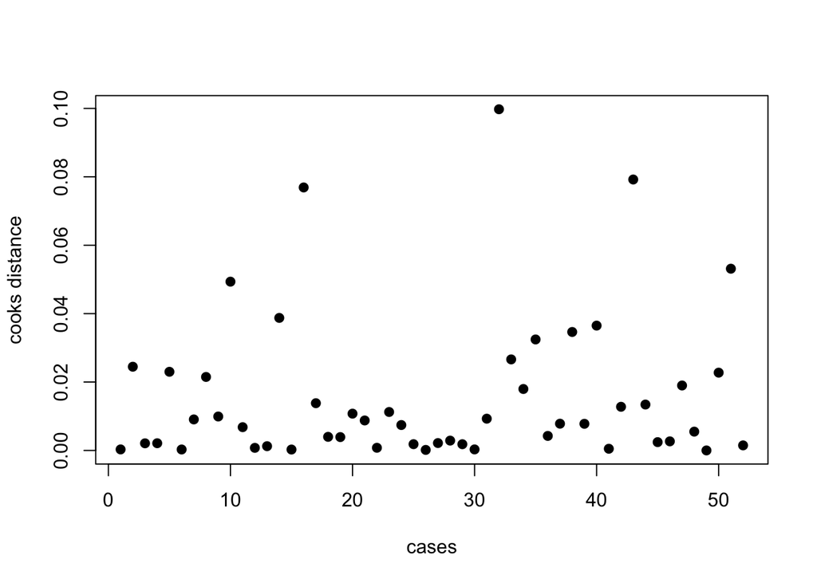

```r
ck=cooks.distance(fit.1010)
plot(c(1:n.1010a),ck, xlab = "cases",ylab = "cooks distance", pch=19)
```

The plot show that all cook’s distance is below 10% and there are little influence on the fitted value.

# 10.16

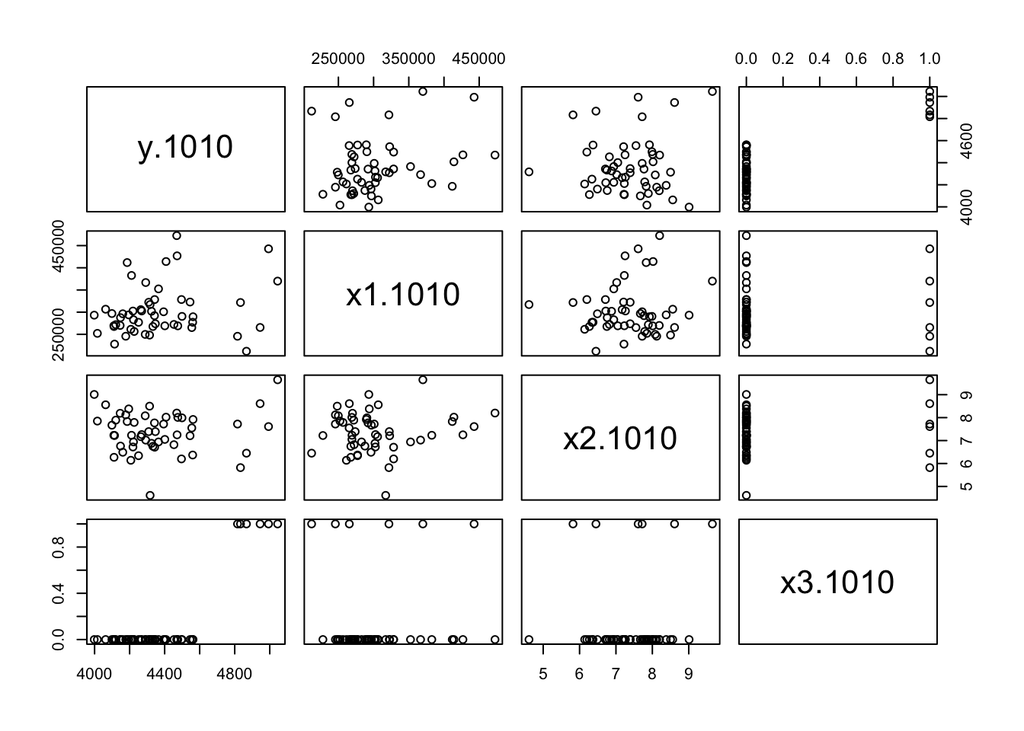

```r
pairs(data.1010)
```

```r
cor(data.1010)
```

```
##            y.1010    x1.1010    x2.1010    x3.1010
## y.1010  1.0000000 0.20766494 0.06002960 0.81057940
## x1.1010 0.2076649 1.00000000 0.08489639 0.04565698
## x2.1010 0.0600296 0.08489639 1.00000000 0.11337076
## x3.1010 0.8105794 0.04565698 0.11337076 1.00000000
```

From the plot, x1 and x2 may have multicollinearity but need to be determined.

```r
vif= rep(0,3)
vif[1]=1/(1-summary(lm(x1.1010~x2.1010+x3.1010,data = data.1010))$r.squared)
vif[2]=1/(1-summary(lm(x2.1010~x1.1010+x3.1010, data = data.1010))$r.squared)
vif[3]=1/(1-summary(lm(x3.1010~x2.1010+x1.1010, data= data.1010))$r.squared)
vif
```

```
## [1] 1.008596 1.019598 1.014364
```

There are no multicollinearity in x1, x2 and x3.